# Домашка по теорверу на 01.03.17

```python
import numpy as np
import seaborn as sns
%pylab inline
```

## Задача 7

Дана последовательность случайных величин $X_n$, заданных на одном и том же вероятностном пространсте $(\Omega, F, P)$. Подобрать такую последовательность чисел $c_n$, что $\frac{X_n}{c_n}$ сходится к $0$ почти наверное.

Выберем убывающую последовательность ${\{\epsilon_i\}} = \frac{1}{i^2}$. Для каждого $i$ найдем такое событие $A_i$, что $P(A_i) \ge 1 - \epsilon_i $. Т.к. $X_i$ случайная величина, то для любого интервала $(a, b): X_i^{-1}(a, b) \in F$. Событие $A$ сформируем как образ некоторого интервала с большой вероятностью. Т.к. $X_i^{-1}(-\infty, +\infty) = \Omega$, то: $$\exists l, r: P(X_i^{-1}(l, r)) \ge 1 - \epsilon$$. Возьмем в качестве $c_i$ тогда $$\frac{2\max(|l|, |r|)}{\epsilon}$$.

Чтобы показать сходимость к $0$ последовательности $\frac{X_n}{c_n}$ для начала рассмотрим последовательность событий $B_i = \{w \mid \frac{X_i(w)}{c_i} \ge \epsilon_i\}$. По построению последовательности $c_i$ имеем, что $P(B_i) < \epsilon_i$. Но тогда $$\sum_{i=1}^{\infty} P(B_i) \le \sum_{i=1}^{\infty} \frac{1}{i^2} < \infty$$ Значит можно воспользовать первой леммой Бореля-Кантелли. Таким образом мера элементарных исходов, на которых нарушается сходимость $P(B) = 0 \rightarrow$ последовательность сходится к $0$ почти наверное.

## Задача 8

Дана последовательность случайных величин $\{X_n\}, X_i \ge 0, \forall \omega: X_i(\omega) \le X_{i+1}(\omega)$ и $\forall i: E(X_i) < C_e$. Нужно доказать, что эта последовательность сходится почти всюду, а предел матожидания равен матожиданию предела.

Докажем первую часть. Для этого докажем, что **почти всюду** последовательность случайных величин ограничена, т.е. $P(\{\omega \mid \forall i: X_i(\omega) < C_\omega \}) = 1$. Если это так, то в силу монотонности случайных величин получим, что для каждого элемента $\omega$ за исключением подмножества меры нуль, будет существовать предел (функция ограничена и монотонна). Т.е. последовательность случайных величин будет иметь предел в значении сходимости почти наверное.

Чтобы доказать необходимое нам утверждение, воспользуемся аналогичным приемом, как в задаче 7.

Определим последовательность возрастающих чисел $\{C_i\} = i^2$. Рассмотрим множество $A_t^i = \{\omega \mid X_t(\omega) > C_i \}$. Воспользуемся [неравенством Маркова](https://ru.wikipedia.org/wiki/%D0%9D%D0%B5%D1%80%D0%B0%D0%B2%D0%B5%D0%BD%D1%81%D1%82%D0%B2%D0%BE_%D0%9C%D0%B0%D1%80%D0%BA%D0%BE%D0%B2%D0%B0). В таком случае $P(A_t^i) \le \frac{E(X_t)}{C_i} \le \frac{C_e}{C_i}$.

Рассмотрим также предельный случай: множество $A^i = \{\omega \mid \exists t: X_t(\omega) > C_i \}$.

$$P(A^i) = \lim_{t \rightarrow \infty} A_t^i \le \frac{C_e}{C_i} = \frac{C_e}{i^2}$$

Здесь воспользуемся опять леммой Бореля-Кантелли: $P(A) = 0$, где $A = \{\omega \mid \forall C > 0 \exists k: X_k(\omega) > C \}$. Значит **почти всюду** случайная величина ограничена.

Чтобы показать, что $\lim_{t \rightarrow \infty}(E(X_t)) = E(\lim_{t \rightarrow \infty}(X_t))$ покажем, что $\lim_{t \rightarrow \infty}(\int_{A} X_t(\omega) P(d\omega)) = 0$. Это так, потому что для любого $t$, если $\int_{A} X_t(\omega) P(d\omega) > 0$, то можно пропорционально увеличить значения случайной величины для каждого элемента $A$, чтобы интеграл превзошел любое наперед заданное число, что противоречит с тем, что матожидания ограничены в совокупности.

Но тогда мы можем забыть про это подмножество вероятностного пространства, а т.к. за исключением него последовательность сходится поточечно и матожидание ограничено, то предел матожидания будет равен матожиданию предела.

## Задача 9

Подобрать такую последовательность событий $\{A_i\}$ такую, что $P(A_i) \rightarrow 1$, но $\forall k: \cap_{i \ge k} A_i = \emptyset$

Подходит конструкция, похожая на конструкцию с индикаторами на паре:

Рассмотрим равномерное распределение на интервале $(0, 1)$, т.е. $(\Omega, F, P)$, где $\Omega = (0, 1)$, $F = B(0, 1)$ - борелевская сигма-алгебра интервала, а $P$ - "длина" системы интервалов из $F$ (мера Лебега). Определим последовательность событий следующим образом: $$A_{ij} = (0, \frac{j - 1}{i}) \cup (\frac{j}{i}, 1)$$, для всех $1 \le j \le i$. Линейная последовательность определяется следующей подпоследовательностью данных событий: $\{B_i\} = \{A_{11}, A_{21}, A_{22}, A_{31}, A_{32}, \cdots \}$

```python
def draw_plot(i, j, ax):
    ax.axis('off')
    if i < j:
        return
    xs = np.linspace(0, 1, 500)
    ys = np.piecewise(xs, [xs < (j - 1) / i, ((j - 1) / i <= xs) & (xs <= j / i), j / i < xs], [1, 0, 1])
    ax.plot(xs, ys)
```

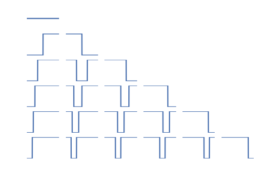

```python
grid_size = 6
f, ax = subplots(grid_size, grid_size)
for i in range(grid_size):
    for s in range(grid_size):
        draw_plot(i + 1, s + 1, ax[i][s])
```

Несложно видеть, что $P(B_i) \rightarrow 1$. Также несложно видеть, что для каждого элементарного события $\omega$ и для любого наперед заданного $n$ существует такое $k \ge n$, что $\omega \notin B_k$, значит $\cap_{i \ge k} B_i = \emptyset$

## Задача 10

Вложили капитал $K$. Получаем $X\%$ годовых, где $X$ равновероятно принимает значения из $\Omega = \{-50, -40, -30, -20, -10, 0, 10, 20, 30, 40, 50, 60\}, |\Omega| = 12$.

Наш капитал ведет себя по закону $K_{i+1}=K_i(1 + \frac{X_i}{100})$. При условии, что $X_i$ независимы, найти $\lim_{t \rightarrow \infty} E(K_t)$. Также найти случайную величину, к которой почти наверное сходится $K_t$.

Начнем с матожидания. Т.к. $X_i$ независимы, то $$E(K_{i+1}) = E(K_i(1 + \frac{X_i}{100})) = E(K_i) E(1 + \frac{X_i}{100}) = E(K_i)E(\frac{12 + 60/100}{12}) = \frac{21}{20}E(K_i)$$

Значит $E = \lim_{t \rightarrow \infty}E(K_t) = \infty$

```python
from itertools import product
def capital_expectation(size):
    variants = product(np.arange(-5, 7), repeat=size)
    return np.average(list(map(lambda l: np.prod(1 + np.array(l) / 10), variants)))
```

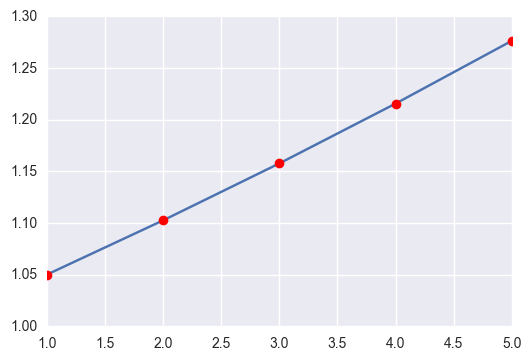

```python
# синия линия - предсказанная нами зависимость, красные точки - реальное ожидание капитала

xs = np.arange(1, 6)
ys_actual = [capital_expectation(x) for x in xs]
ys_expected = [(21/20)**x for x in xs]
plot(xs, ys_expected)
plot(xs, ys_actual, marker='o', color='r', ls='');
```

К сожалению, поставить численный эксперимент для больших выборок не удастся, так как несмотря на то, что матожидание стремится к бесконечности, оно почти наверное сходится к нулю.

## Задача 11

Число $\alpha \in [0, 1]$ называется диофантовым, если существуют такие $c, \epsilon > 0$, что для любого рационального числа $\frac{p}{q}$ выполняется неравенство $$|\alpha - \frac{p}{q}| \ge \frac{c}{q^{2+\epsilon}}$$.

Нужно показать, что мера диофантовых чисел равна $1$.

Зафиксируем $c = 1, \epsilon = 1$. Определим множество $$A_q^{c\epsilon} = \{\alpha \textit{ для которых нарушается критерий диофантовости относительно знаменателя } q\} = \{\alpha \mid \exists p: |\alpha - \frac{p}{q}| < \frac{c}{q^{2+\epsilon}}\}$$

Несложно оценить меру $P(A_q^{c\epsilon}) \le q \frac{2c}{q^{2+\epsilon}} = \frac{2c}{q^{1+\epsilon}}$

Тогда $$\sum_{i=1}^{\infty} P(A_i) < \infty \rightarrow P(A) = 0$$ где $$A = \{\alpha \mid \exists \{p, q\}_{n_k}: |\alpha - \frac{p}{q}| < \frac{c}{q^{2+\epsilon}} \}$$

Числа из множества $A$ просто выкинем, т.к. оно имеет меру $0$. Осталось показать, что во множестве $[0, 1] \setminus A$ почти все числа - диофантовы. Но на самом деле несложно видеть, что там **все** числа диофантовы, т.к. заметим, что если для некоторых $c, \epsilon, \alpha$ множество знаменателей, на которых нарушается условие диофантовости конечно - то можно подобрать такие $c', \epsilon'$, что с учетом этих констант число $\alpha$ будет диофантовым. Т.е., если $$B_{\alpha} = \{ q \mid \exists p: |\alpha - \frac{p}{q}| < \frac{c}{q^{2+\epsilon}} \}, |B_{\alpha}| < \infty$$ Так как для каждого $q$ существует не более одного $p$, нарушающего условие диофантовасти для заданного $\alpha$, то множество $$B_{\alpha}' = \{ p, q \mid |\alpha - \frac{p}{q}| < \frac{c}{q^{2+\epsilon}} \}$$ имеет такую же мощность как $B_{\alpha}$

Но тогда достаточно положить $$\epsilon' = \epsilon, c' = \min_{p, q \in B_{\alpha}'} \{ |\alpha - \frac{p}{q}| / \frac{1}{q^{2+\epsilon}} \}$$

Т.к. множество $B_{\alpha}'$ - конечно, то такое преобразование корректно. Значит все числа в $[0, 1] \setminus A$ - диофантовы.